# 世界城堡 探索性可视化

TidyTuesday · 2026-09-01 (Week 36)

作者

zlZayn

发布于

2026年9月20日

# 5,793 座城堡：大陆从点里浮出来，时间要等到 AD 1000 才开始堆

## 数据范围与四个会影响读图的口径

数据是 `world_castles.csv`（5,793 行 × 15 列，138 个 `country` 取值）。看图之前有四件事必须先交代清楚，否则图会被误读：

1. **`category` 恰好 4 类**：castle 2591、fortress 1180、palace 934、ruin 1088 —— 四类互不重叠，没有第五类，也不需要合并。
2. **年代缺口集中在一处**：2,183 行（37.7%）既没有 `year` 也没有 `century`，两个字段的空值逐行同步 —— 这是同一批遗址的整段年代缺测，而不是两个独立问题。
3. **`century` 不提供 `year` 之外的信息**：按「第 n 世纪 = (n−1)×100+1 … n×100」复核，两者在 3,610 行上零不一致，覆盖的却是同一批行；`century` 里还有 1 行不存在的标签 `0th century`（Tokat Castle，`year = 0`）。所以时间轴一律用数值 `year`。
4. **年代是粗刻度**：整百年有 506 行（14.0%），能被 50 整除的有 927 行（25.7%）；而 `year_approx = 1` 只标了 508 行，其中落在整百年上的只有 30 行 —— 近似标记远没有覆盖真正的粗刻度。

`lat` / `lon` 零缺失，所以地图上 5,793 个遗址一个都不用丢。

## 主图：先把大陆点出来，再让时间堆起来

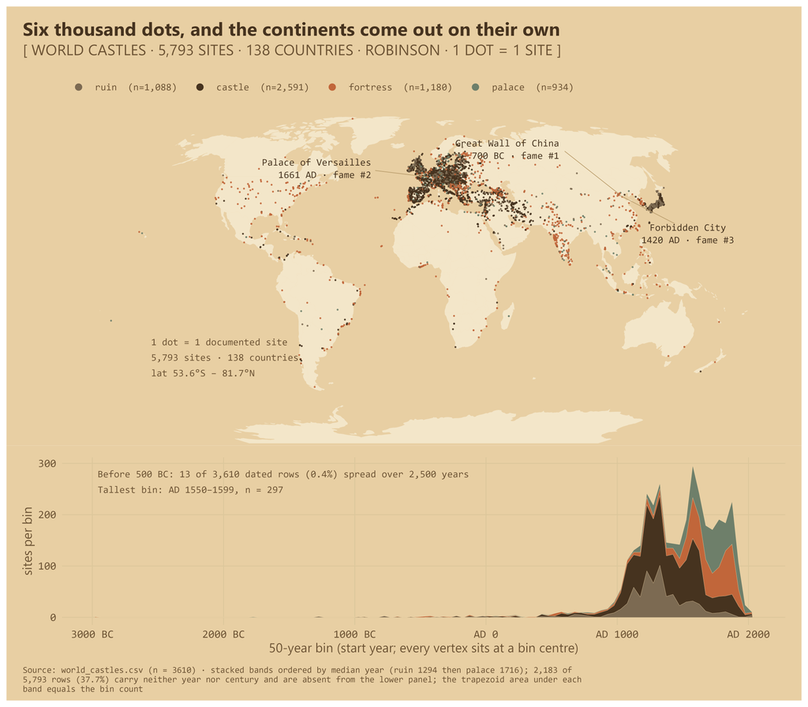

图 1: Top: every documented site as one dot on a Robinson projection, continents left faint so the dot field draws the outline. Bottom: the same catalogue on a 50-year time axis, split by category — the first four millennia are almost empty and everything piles up after AD 1000.

**读数**：上半张图里 5,793 个点不需要任何边框就已经把欧亚大陆的西缘、日本列岛和北非海岸线画了出来 —— 点密度本身就是地图。下半张图的故事更硬：**3,610 行有年代的遗址里，500 BC 之前只有 13 行（0.4%），却横跨 2500 年**；101 个 50 年箱里只有 59 个非空，最高的一个箱是 AD 1550–1599（297 座）。时间轴的左半张几乎是一段空白 —— 那不是绘图失误，那就是结论：**这份目录是 AD 1000 之后的目录**。

## 三成八的遗址没有年代，而且宫殿与城堡差近一倍

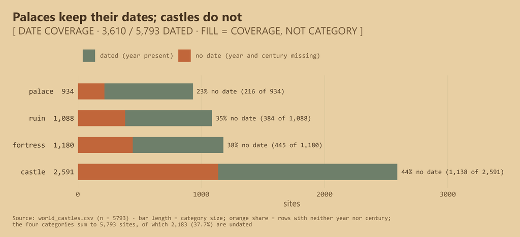

图 2: Date coverage by category, bars ordered by how much of each category is undated. Green is a row with a year, brick orange is a row with neither year nor century.

**读数**：缺年代的比例**不是均质的** —— ruin 35.3%、fortress 37.7%、castle 43.9%、palace 只有 23.1%。宫殿是最容易被写进文献并留下确切年份的一类，城堡（尤其欧洲乡间的中小城堡）差了一倍。**这意味着主图下半张的时间轴在类别构成上是有偏的：宫殿被过度代表。** 这一偏倚在主图的时间轴上无法回避，读者需要带着它读下半张图。

## 关注度不随年代走

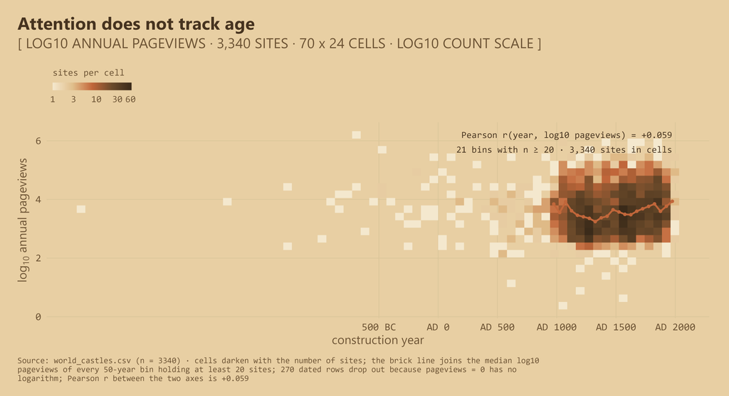

图 3: log10 annual pageviews against construction year: the point cloud stays vertical in every period, so age carries almost no information about attention.

## 方法与口径

| 项 | 值 |
| --- | --- |
| 数据 | `data/world_castles.csv`（5,793 × 15；138 个 `country` 取值、137 个 `iso` 取值） |
| 入图（地图） | 5,793 个遗址全部入图：`lat` / `lon` 零缺失，无需筛选 |
| 入图（时间轴） | 3,610 行；raw 5793 -> plotted 3610 (2,183 行既无 year 也无 century) |
| 入图（关注度热图） | 3,340 行；raw 5793 -> plotted 3340 (2,183 行无年代; 270 行有年代但 pageviews = 0，取不了 log10) |
| 口径差（必须分清） | **原始 5,793** = castle 2591 + fortress 1180 + ruin 1088 + palace 934；**时间轴 3,610**；**热图 3,340**。图上图例与脚注一律按各自面板的口径报数 |
| 为什么地图与时间轴在同一张图上 | 上半是点阵世界地图、下半是同一份目录的时间轴堆叠面积，两者共用一条图例，主图脚注一次交代两个面板的口径 |
| century 为什么不用 | 35 个取值全部可解析，且与 `year` 在 3,610 行上零不一致 —— 它不提供 `year` 之外的信息，却含 1 行 `0th century`（Tokat Castle，`year = 0`）；时间轴一律用数值 `year` |
| 投影与底图 | 地图用 Robinson 投影；底图取 Natural Earth 1:110m 国界，极淡米色填充、不描边、去轴去网格；1 个点 = 1 个遗址 |
| 图上没有画的 | 任何未出现在数据里的注释地名；地标标注只取 `fame_rank` 前 3 行 |